# A3: SPL Library Checkouts

Aaron Lee

### Introduction

I’ve decided that I’m going to use the dataset with the items that have been checked out at least 10 times a month. I’ve decided to use this dataset because the dataset I wanted to use is unfortunately not loading from the database. Additionally, I think it’s just more useful to look at relevant works (works that get checked out frequently) than obscure, irrelevant works.

### Summary Information

When I first see a large dataset like this, one of my first thoughts are: what are the extremes? Thus, in my findings, I found the the “most” of the variables. First, I looked at time. I found that the year that had the most checkouts in total was **2019** with **3673267** checkouts. I then went smaller and found that December on average has the most checkouts with **24.4359772** checkouts. My guess to this is because of Christmas books and movies being rented.

### The Dataset

This data was collected by the Seattle Public Library from their database. It collects all the checkouts that have been made from 2017 to 2023. This includes not only books, but also ebooks, audiobooks, movies, and more. The purpose of collecting this data is so it can be used on “Seattle Open Data” a website that provides data to the public so people outside of the government can help solve “civic” problems. Another reason is so the city can be transparent to its residents when it comes to information and data.For each checked out item, the database tracks mulitple parameters including the checkout year, checkout month, title, creator, item type, publisher, publication year, and more.

Although I don’t have any ethical questions, I am concerned by the messy and unorganized structure of the database. For example, the publication years have different formats and the titles have a lot of information other than the title so it can be hard to read.

### First Trends Over Time Chart

The first question that I wanted to ask was: How do checkout numbers compare between material types (books, movies, ebooks)? To answer this question I calculated the total number of checkouts of each material type over each month to not only get a sense of general popularity, but popularity over time (Note: for simplicity and cleanliness sake, I only included the 4 most checked-out material types.)

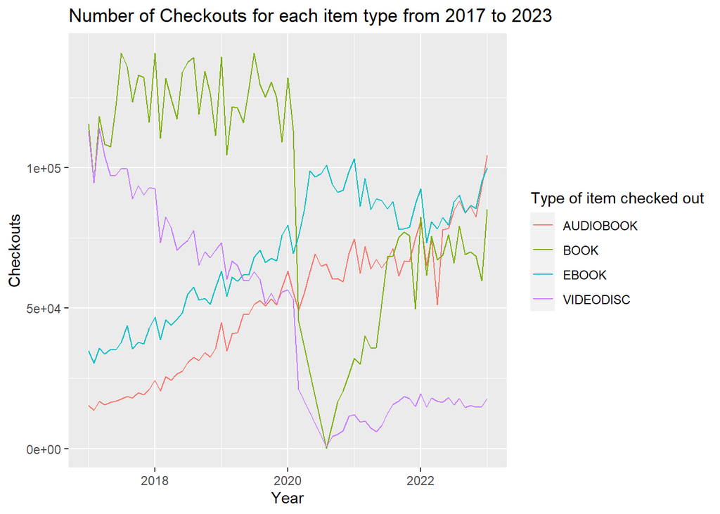

Looking at the graph, we can see some very interesting trends and observations. First, we can see that at the start of the pandemic (early 2020) we see that both audiobooks and ebooks increase in checkouts while both books and video discs take a massive dive. This makes sense since library shut downs during the pandemic would logically result in less checkouts for physical items (books and discs) while digital items (audiobooks and ebooks) wouldn’t be affected.

Another trend that sticks out is that after the initial dip for books and discs, we see that books made a swift recovery but discs plateaued. My guess to this is that many people acquired streaming service subscriptions during the pandemic so they didn’t need to rent discs anymore.

### Second Trends Over Time Chart

The second question I wanted to ask was: How do the checkouts compare between JK. Rowling and J.R.R. Tolkien? Both of these authors are two of the most popular authors of all time, each of them with world-renowned book series. However, I wanted to see whose books were more popular.

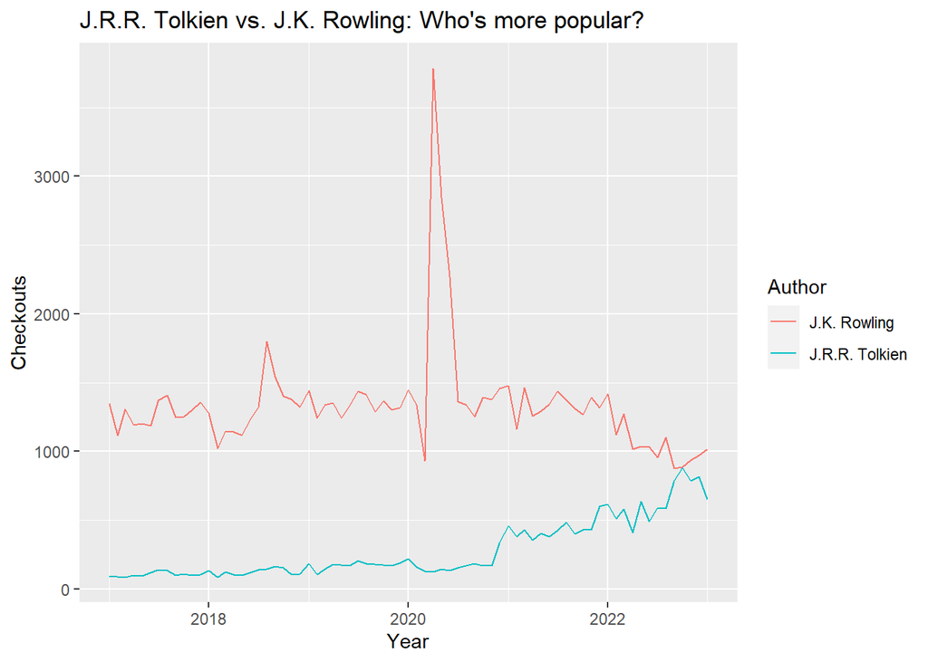

One of the most obvious features of this graph is the massive spike in checkouts for J.K. Rowling’s work. This coincides with the start with the pandemic so my guess is that many people started re-reading the Harry Potter books with the down time that they had. However, J.R.R. Tolkien’s books did not spike the same way. The argument could be made that the Lord of the Rings is not as popular as the Harry Potter series but I’m still shocked that that there is barely a rise in checkouts.

### Your Choice

For my last choice, I watned to examine how people prefer to consume literature. Specifcally. do people prefer physical books, audiobooks, or ebooks? I was interested to see the data for this question because there seems to be an idea that people are reading books less and less. But does that mean that they’re now listening to audio books? Maybe people prefer tablets (ebooks)? The data below shows the total number of checkouts for each medium from 2017 to 2023:

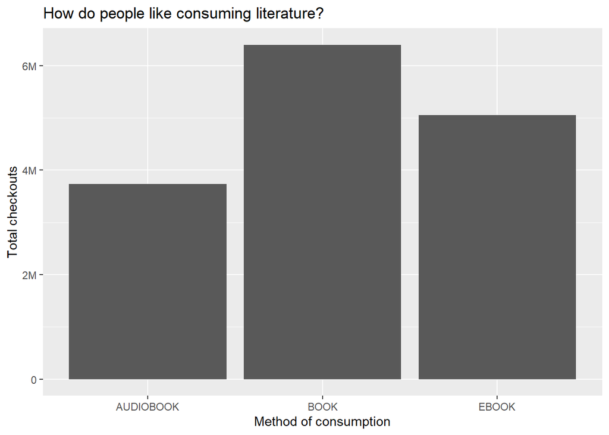

As seen in the graph, the physical book, is still the preferred method of consuming literature, while ebooks and audiobooks are second and third, respectively. However, this is data from only the Seattle Public Library; ebooks and audiobooks are easily accessible from other resources (i.e., Amazon and Spotify) so it would be wrong to conclude that this graph is representative of the general population.